# Phy 491 hw 1 - Andrew Koren

Phy 491 HW 1

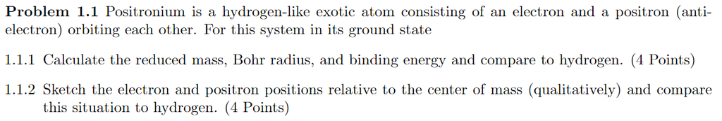

1.1.1  
Reduced mass: $\mu = \frac{1}{\frac{1}{m_1}+\frac{1}{m_2}}$

For Positronium  
$m_1 = m_2 = m_e $  
$\mu = \frac{1}{\frac{2}{m_e}}=\frac{m_e}{2} = 4.55*10^{-31}$

Bohr radius: For hydrogen the fomula I found online has $a_0 = \frac{4\pi\epsilon_0\hbar^2}{m_ee^2}$, which would be the same as hydrogen aside from using $\mu = \frac{m_e}{2}$ instead of $m_e$, yielding double the radius of hydrogen, but I want to verify.

Bohr radius is really just the distance where the force between the two particles keeps them rotating, which depends on the coulomb force. $$ %F_{r} = \frac{\mu v^2}{r}\\ %F_{E} = k\frac{e^2}{r^2} \\ \frac{\mu v^2}{r} = k\frac{e^2}{r^2} $$ $$r = \frac{\mu v^2 r^2}{ke^2} = \frac{(\mu v r)^2}{k\mu e^2}$$

Using $\mu vr = n\hbar$ since this is hydrogen-like, we have

$$ r_n = \frac{n^2\hbar^2}{k\mu e^2} \\ r_1 = \frac{4\pi\epsilon_0\hbar^2}{\mu e^2} = 2\frac{4\pi\epsilon_0\hbar^2}{m_e e^2} = 2 a_0 $$

Binding energy: Not a formula typically, but we can use the same formula as the binding energy of hydrogen due to it being a hydrogen-like sytem. From Mcintyre this time:

$$ E_n = -\frac{1}{2n^2}\left(\frac{1}{4\pi \epsilon_0}\frac{e^2}{a_0}\right) $$ We substitute ${a_0}$ with our smallest radius $r_1=2a_0$ and find the smallest energy value possible is $$ E_1 = -\frac{1}{4}\left(\frac{1}{4\pi \epsilon_0}\frac{e^2}{a_0}\right) $$ Which is clearly 1/2 that of hydrogen, at -6.8eV

1.1.2

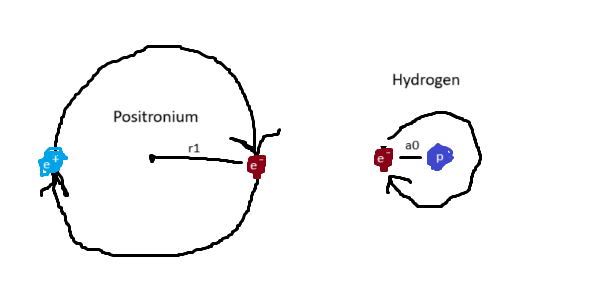

Really they are 4x further apart, since the Bohr radius is distance from center of mass to reduced mass, and the positron does not sit at the center like the hydrogen

I am curious about the radius of Protonium now,

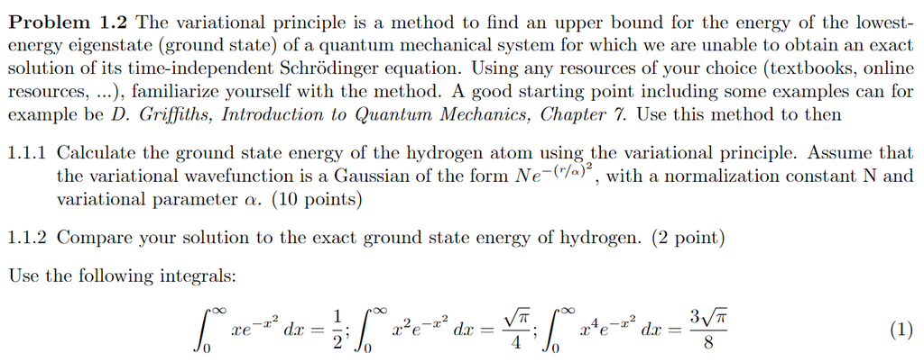

1.1.1  
We will be minimizing $\langle \Psi | H | \Psi \rangle$ using $|\Psi(r)\rangle = Ne^{-(r/\alpha)^2}$

All we really have to do is find the energy as a function of $\alpha$ and then find the minimum. Can't be that hard. I hope the independence with $\theta$ and $\phi$ make this easier.

First, lets find our normalizing constant.

$$ \langle \Psi | \Psi \rangle = N^2 \int_0^\infty e^{-2(r/\alpha)^2} dV \\ dV = r^2 dr \text{ simplified} $$ We can't quite integrate that yet since we need to get that $2$ and $\alpha$ out.

$$ u = \sqrt{2} r/a \rightarrow r = \frac{au}{\sqrt{2}} \\ dr = \frac{adu}{\sqrt{2}}\\ \int_0^\infty r^2 e^{-2(r/a)^2}dr = \frac{a^3}{2\sqrt{2}}\int_0^\infty u^2 e^{-u^2}dr = \frac{a^3}{2\sqrt{2}} \frac{\sqrt{\pi}}{4} \\ \langle \Psi | \Psi \rangle = N^2\frac{a^3}{2\sqrt{2}} \frac{\sqrt{\pi}}{4} = 1 \\ N^2 = \frac{8\sqrt{2}}{a^3\sqrt{\pi}} \\ |N| = \sqrt{\frac{8\sqrt{2}}{a^3\sqrt{\pi}}} $$ Sweet! Now for the rest of the problem

Since $\frac{\partial}{\partial \theta}\Psi(r) =\frac{\partial}{\partial \phi}\Psi(r)=0$, the hamiltonian becomes

$$ H = -\frac{\hbar^2}{2\mu}\frac{1}{r^2}\frac{\partial}{\partial r}\left(r^2\frac{\partial}{\partial r} \right) - \frac{e^2}{4\pi \epsilon_0 r} $$

However, the professor wrote on the board

$$ H = - \frac{\nabla^2}{2}-\frac{1}{r} = -\frac{1}{2r^2}\frac{\partial}{\partial r}\left(r^2\frac{\partial}{\partial r} \right) - \frac{1}{r} $$

To convert from Hatree energy units (atomic units) to eV, one need only multiply by $27.2114$. Google says our result should be somewhere around $-0.5E_h$

$$H|\Psi\rangle = \left[-\frac{1}{2r^2}\frac{\partial}{\partial r}\left(r^2\frac{\partial}{\partial r} \right) - \frac{1}{r} \right] Ne^{-(r/\alpha)^2}$$

Wolfram can do all the heavy lifting here

$$ = -\frac{3Ne^{-\frac{r^2}{a^2}}}{a^2} + \frac{2Nr^2e^{-{\frac{r^2}{a^2}}}}{a^4}- \frac{Ne^{-\frac{r^2}{a^2}}}{r} $$

Wolfram also reports it's a Laurent series, but I don't really care  
Next we measure with the original wave function

$$ \langle \Psi |H| \Psi \rangle = -4 \pi \int_0^\infty \left[Ne^{-(r/\alpha)^2} \right]\left[\frac{3Ne^{-\frac{r^2}{a^2}}}{a^2} - \frac{2Nr^2e^{-{\frac{r^2}{a^2}}}}{a^4} - \frac{Ne^{-\frac{r^2}{a^2}}}{r}\right] r^2 dr $$ Let's separate out the kinetic energy and potential energy term, since my previous attempt to work through this didn't turn out right.

For $T$:

$$ \langle \Psi |T| \Psi \rangle = -4\pi N^2 \int_0^\infty 3r^2 e^{-2r^2/a^2}dr + 4\pi N^2\int_0^\infty\frac{2}{a^2} r^4 e^{-2r^2/a^2}dr \\ = \frac{12 \pi N^2}{a 2^{3/2}} - \frac{8 \pi N^2}{a 2^{5/2}} \\ = 4\pi N^2 a \frac{6\sqrt{\pi}}{32\sqrt{2}} $$

FOr $V$:

$$ \langle \Psi |V| \Psi \rangle -4\pi N ^2 \int_0^\infty r^2 e^{-2r^2/a^2}\frac{1}{r} dr \\ = -4\pi N^2 \left( \frac{a}{\sqrt{2}} \right) \int_0^\infty xe^{-u^2} du = - 4\pi N^2 \left(a^2/4 \right) $$

Now we can normalize (with the help of wolfram)

$$ \frac{4\pi N^2 a \frac{6\sqrt{\pi}}{32\sqrt{2}} + - 4\pi N^2 \left(a^2/4 \right)}{\frac{8\sqrt{2}}{a^3\sqrt{\pi}}} = \frac{3}{2a^2} - \sqrt{\frac{8}{\pi}}\frac{1}{a} $$

This is a much nicer expression!

$$E' = -\frac{3}{a^3} + \frac{2^{3/2}}{\sqrt{\pi}a^2} =0 $$

$$ a = \frac{3\sqrt{\pi}}{2^{5/2}} \rightarrow E = -\frac{4}{3\pi} = 0.424 E_h $$

Great!!! This is $-11.5eV$. The actual ground state energy is $-13.6$, so it is off by only $2.1eV$.

## Notice: Something below is incorrect, so I redid the whole thing

$$ = 4 \pi N^2\left[ \int_0^\infty 3r^2\frac{e^{-\frac{2r^2}{a^2}}}{a^2}dr - \int_0^\infty r^2\frac{e^{-\frac{2r^2}{a^2}}}{r}dr - \int_0^\infty 2r^4\frac{e^{-\frac{2r^2}{a^2}}}{a^4}dr \right] \\ = 4 \pi N^2\left[ \int_0^\infty \frac{3}{2}a^2u^2\frac{e^{-u^2}}{a^2}dr - \int_0^\infty \frac{1}{2}a^2u^2\frac{e^{-u^2}}{r}dr - \int_0^\infty \frac{a^4u^4}{2}\frac{e^{-u^2}}{a^4}dr \right] \\ = 4 \pi N^2\left[ \frac{3a}{2\sqrt{2}}\int_0^\infty u^2e^{-u^2}du - \frac{a^2}{2}\int_0^\infty u e^{-u^2}du - \frac{a}{2\sqrt{2}}\int_0^\infty u^4e^{-u^2}du \right] \\ = 4 \pi N^2\left[ \frac{3a}{\sqrt{2}}\frac{\sqrt{\pi}}{4} - \frac{a^2}{4} - \frac{a}{2\sqrt{2}}\frac{3\sqrt{\pi}}{8} \right] $$ Using the normalization we found eariler, this becomes

$$ = 4 \pi \frac{8\sqrt{2}}{a^3\sqrt{\pi}}\left[ \frac{3a}{\sqrt{2}}\frac{\sqrt{\pi}}{4} - \frac{a^2}{4} - \frac{a}{2\sqrt{2}}\frac{3\sqrt{\pi}}{8} \right] $$

Now all that is left is finding the value of $a$ which minimizes this function. This can be done by taking the derivative, or numerically. Either way, I'm really hoping to get close to $-0.5E_h$.

Oh no. The minimum of this function is $-0.1414 E_h$ when $a = 5.63991$. This converts to $-3.84eV$, which has a relative error of 0.71. I could try fanagling the units, but I'm better off looking back through my work.

Someone on the internet https://pleclair.ua.edu/PH253/Notes/variational.pdf has their own work-through, but they don't try to do this atomic units thing.

One thing they got right: doint the actual 3D integral. We need to multiply by $4\pi$ to integrate through space. I went ahead and put the $4\pi$ terms in retroactively

$$ \int_0^{\pi} \int_0^{2\pi} sin(\theta) d\theta d\phi = 4\pi $$

This yields

$$ \langle \Psi| \Psi \rangle = \frac{\sqrt{\pi}}{4} \frac{4\pi N^2}{2\sqrt{2}}a^3 \\ \rightarrow N^2 = \frac{8 \sqrt{2}}{4 \pi \sqrt{\pi} a^3} = \frac{2 \sqrt{2}}{ \pi^{3/2} a^3} $$

and

$$ \langle \Psi | H | \Psi \rangle = 4\pi N^2\left[ \frac{3a}{\sqrt{2}}\frac{\sqrt{\pi}}{4} - \frac{a^2}{4} - \frac{a}{2\sqrt{2}}\frac{3\sqrt{\pi}}{8} \right]\\ = \frac{8\sqrt{2}}{a^3\sqrt{\pi}}\left[ \frac{3a}{\sqrt{2}}\frac{\sqrt{\pi}}{4} - \frac{a^2}{4} - \frac{a}{2\sqrt{2}}\frac{3\sqrt{\pi}}{8} \right] $$ So no luck there.